# Course Overview & Software Setup

STAT3009 · Recommender Systems

Ben Dai

CUHK · Department of Statistics and Data Science

## Every platform chooses what to show next

01 · COURSE PURPOSE

products music connections films investments

AMAZON · ALIBABA · NETFLIX · SPOTIFY · LINKEDIN · FINANCE

Recommendation turns many possible choices into a useful next decision.

## The semester moves from baselines to neural recommenders

COURSE MAP

FOUNDATIONS

### Frame the problem

Interaction data  
Evaluation  
Mean baselines

LATENT STRUCTURE

### Learn hidden preferences

Cross-validation  
SVD and matrix factorization  
MovieLens

NEURAL RS

### Add expressive models

Neural networks  
Neural matrix factorization  
Side information

STATISTICS**×**MACHINE LEARNING**×**CODE

## How this course works

02

Understand the expectations before we begin the technical work.

## You will learn, build, and evaluate

01

### LEARN

Concepts in slides and notes

02

### BUILD

Live Python in Colab and Jupyter

03

### EVALUATE

Notebook exercises and model comparison

[Course homepage ↗](https://www.bendai.org/CUHK-STAT3009/)·[GitHub repository ↗](https://github.com/statmlben/CUHK-STAT3009)

## Bring foundations—not prior recommender-system experience

WHAT HELPS

### We build from tools you have already seen

You do not need to arrive as a recommender-systems expert.

Python-library tutorials are provided when we need them.

**01****Statistics**  
Linear and ridge regression; hypothesis testing

**02****Programming**  
Python, NumPy, Pandas, basic scikit-learn

**03****Mathematics**  
Linear algebra, calculus, probability

## Assessment rewards implementation

**15%**Homework

**40%**Midterm Jupyter  
Notebook examinationApproximately mid-semester  
Two A4 sheets of notes

**45%**Final in-class  
coding quizLast class of the semester

[Midterm format and examination rules](https://www.bendai.org/CUHK-STAT3009/grading/)

## Use AI as a tutor—not a substitute for understanding

AI-ASSISTED · STUDENT-OWNED

USE IT TO**Question · compare · debug**

Ask for an explanation of an error, compare two approaches, or improve the clarity of your Markdown.

VERIFY IT**Run · inspect · test**

Execute every cell, read the output, check assumptions, and test the suggestion on the actual data.

OWN IT**Explain · modify · reproduce**

You remain responsible for every submitted result and should be able to adapt the code yourself.

**Not evidence of learning:** submitting generated work that you cannot reproduce, justify, or debug.

Follow each assessment’s stated tool and disclosure rules. During an assessment, use only the tools explicitly permitted.

## Building a knowledge landscape

Know where an idea fits, what it depends on, and what you need to learn next.

| Foundation | Connection in this course | A question you can ask |
| --- | --- | --- |
| **Linear algebra** Vectors and inner products | Matrix factorization Represents users and items with vectors | What does the predicted score represent? |
| **Probability and statistics** Sampling and uncertainty | Model evaluation Uses held-out data as evidence | Will this result extend to new ratings? |
| **Coding** Arrays, indexing, functions | Computational experiments Turns a model into data operations | Does the program implement the intended experiment? |

A model needs a representation, an implementation, and evidence about its predictions.

Use this map to locate an AI suggestion and identify the knowledge you need to use it.

## Mathematics and coding in the AI era

Mathematics and coding turn your knowledge landscape into something you can reason with and use.

### Mathematics

Define the problem and judge the evidence.

- Connect models to their assumptions and objectives.
- Understand what an evaluation result supports.

Does a lower rating error imply a better recommendation list?

### Coding

Understand and adapt the computation.

- Trace how a modeling idea becomes an experiment.
- Modify the workflow when data or requirements change.

Which observations went into fitting and evaluation?

Use these foundations to guide your questions and extend your understanding with AI.

## Performance on familiar questions

A student can solve every question on the practice sheet.

What would convince you that they can solve new questions?

Try a separate set of questions that was not used for practice.

## The best way to learn code is to wrestle with it

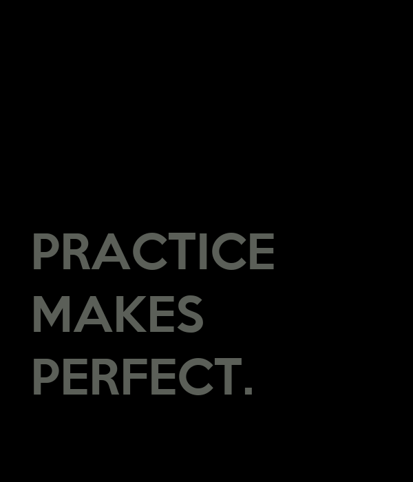

PRACTICE

[figure not shown]

DEBUG

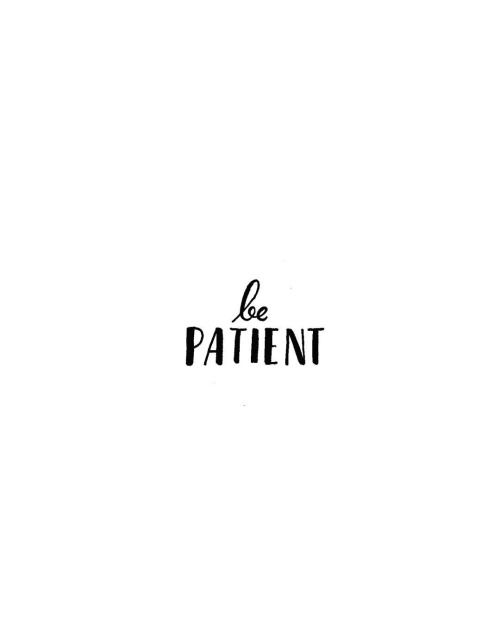

PERSIST

**Bring a laptop.** Read code, run it, break it, fix it—and make it yours.

## Software preparation

03

Use notebooks to keep executable code and readable reasoning together.

## Three layers make a Colab notebook work

ONE COMPUTATIONAL WORKFLOW

LANGUAGE**Python**

The instructions and objects we write.

*lives inside*

DOCUMENT**Jupyter Notebook**

An `.ipynb` file containing code, text, and saved output.

*runs through*

SERVICE**Google Colab**

A hosted notebook interface and computational runtime.

Colab is based on Jupyter; Python is the primary language executed by its kernel.

## A notebook mixes Python and Markdown

JUPYTER NOTEBOOK

PYTHON**Compute**

Import packages, define objects, run models, and create output.

MARKDOWN**Explain**

Write headings, equations, links, interpretation, and task status.

[Open the course notebook in Colab ↗](https://colab.research.google.com/drive/1EDHHDHJf4iYb452fEb70tEC2E9dbuLwK)

STAT3009 · live notebook

[figure not shown]

Source: [Jupyter Project](https://jupyter.org/)

## Use Colab on the web or in VS Code

SAME NOTEBOOK · SAME COLAB COMPUTE

COLAB WEB

### Browser first

1. Open the course notebook below
2. Sign in with Google
3. Save a copy in your Drive
4. Run a cell with **Shift + Enter**

[Open the course notebook ↗](https://colab.research.google.com/drive/1EDHHDHJf4iYb452fEb70tEC2E9dbuLwK)

COLAB FOR VS CODE

### Editor first

1. Install the official **Colab** extension
2. Download the course notebook as `.ipynb`
3. Open it in VS Code
4. Choose **Select Kernel → Colab**
5. Select **Auto Connect** and sign in

[Install the VS Code extension ↗](https://marketplace.visualstudio.com/items?itemName=google.colab)

In Colab: **File → Download → Download .ipynb** gives you a local notebook file.

## Notebook, kernel, and Python environment

AN ANALOGY: MIXING A GLASS OF SUGAR WATER

### Notebook

Instructions & experiment log

The `.ipynb` file stores code, explanations, and saved results.

### Kernel

The person doing the experiment

Runs the code and holds variables in memory, like the current mixture.

### Python environment

Workbench & available tools

Provides the Python interpreter and installed packages the kernel uses.

### Restart the kernel

Start again with an empty cup. Variables disappear. Saved notebook contents remain.

### `%pip install pandas`

Add a tool to the active workbench. The package goes into the kernel’s environment.

## A notebook remembers execution—not visual order

THE KERNEL HOLDS INVISIBLE STATE

01 · RUN CELL`discount = 0.10`

kernel memory → **discount = 0.10**

02 · EDIT, BUT DO NOT RUN`discount = 0.20`

screen → **0.20** · memory → **0.10**

03 · RUN THE NEXT CELL`100 * (1 - discount)`

output → **90.0**, not 80.0

ON SCREEN**Saved cells**

What the notebook currently displays.

IN MEMORY**Executed state**

What the kernel will actually use.

BEFORE SHARING OR SUBMITTING **Restart session → Run all → Verify outputs**

A fresh Colab runtime may also require the package-setup cells again.

## Markdown turns plain text into structure

WHAT YOU TYPE

```markdown
## Preparation

**Goal:** verify the software setup.

- [x] install the packages
- [ ] finish the practice

[Python docs](https://docs.python.org/)

Inline code: `print(version)`

Equation: $y = \beta_0 + \beta_1 x$
```

WHAT THE NOTEBOOK RENDERS

### Preparation

**Goal:** verify the software setup.

- install the packages
- finish the practice

[Python docs](https://docs.python.org/)

Inline code: `print(version)`

y = β₀ + β₁x

## Markdown also handles technical notation

```markdown
### Prediction error

Use `predict(...)` to obtain predictions.

$$
\operatorname{RMSE}
= \sqrt{\frac{1}{n}\sum_{i=1}^{n}
(y_i-\hat y_i)^2}
$$

| symbol | meaning |
|---|---|
| y | observed rating |
| y_hat | predicted rating |
```

**inline code**wrap a short expression in backticks

**display math**wrap an equation in double dollar signs

**pipe table**use vertical bars to separate columns

**blank lines**separate blocks and prevent rendering surprises

## Python refresher

04

Review the small set of patterns we will use from the first lab onward.

## Packages extend what Python can do

```python
%pip install -q numpy pandas seaborn rehline

import numpy as np
import pandas as pd
import seaborn as sns
import rehline

print("NumPy:", np.__version__)
print("Pandas:", pd.__version__)
```

**%pip install**installs into the current notebook environment

**import**loads a package in the current session

**as np · as pd**creates conventional short aliases

**seaborn · rehline**match the dependencies listed in the combined course notebook

## Assignment connects a name to an object

```python
course = "STAT3009"
week = 1
threshold = 3.5
ready = True

# inspect and compare
print(type(course))
print(week == 1)
```

**name = value**assigns an object to a name

**str · int · float · bool**are common scalar types

**==**compares two values

**#**starts a comment

## Expressions transform values

```python
score = 82
bonus = 5

adjusted = score + bonus
passed = adjusted >= 60
in_range = 0 <= adjusted <= 100

message = f"adjusted score: {adjusted}"

print(message)
print(passed, in_range)
```

**+ · - · * · /**perform arithmetic operations

**>= · <= · == · !=**produce Boolean values

**chained comparison**expresses a range naturally

**f”{name}“**inserts an expression into text

## Lists and dictionaries organize values

```python
ratings = [4, 5, 3, 4]
student = {"name": "Ada", "ready": True}

print(ratings[0])        # first item
print(ratings[-1])       # last item
print(ratings[1:3])      # positions 1 and 2
print(student["name"])  # look up a key
```

**list**ordered values indexed by position

**dict**key–value pairs indexed by key

**[start:stop]**includes start, excludes stop

**-1**refers to the last item

## A for loop visits each value once

```python
liked = []

for rating in ratings:
    if rating >= 4:
        liked.append(rating)

for index, rating in enumerate(ratings):
    print(index, rating)
```

**for item in values**iterates over a sequence

**if condition**runs a block only when true

**.append(…)**adds one item to a list

**enumerate(…)**provides both position and value

## Indentation is part of Python syntax

```python
for rating in ratings:
    if rating >= 4:
        label = "liked"
    else:
        label = "other"
    print(label)

print("finished")
```

**:**starts an indented block

**4 spaces**is the recommended indentation

**same level**means the same block

**dedent**leaves the current block

Do not mix tabs and spaces. Python uses indentation to decide which statements belong together.

## Functions package repeated logic

```python
def select_liked(values, threshold=4):
    liked = []
    for value in values:
        if value >= threshold:
            liked.append(value)
    return liked

select_liked(ratings)
```

**def name(…):**defines a function

**parameters**receive inputs

**local names**exist inside the function

**return**sends one result back

## NumPy arrays have shape and dtype

```python
ratings = np.array([4, 5, 3, 4], dtype=float)

print("ndim:", ratings.ndim)
print("shape:", ratings.shape)
print("size:", ratings.size)
print("dtype:", ratings.dtype)

matrix = np.arange(12).reshape(3, 4)
print("matrix shape:", matrix.shape)
```

**ndarray**stores homogeneous values efficiently

**ndim**counts the number of axes

**shape · size**describe dimensions and element count

**dtype**records the common value type

## Axis tells NumPy which direction to summarize

```python
matrix = np.arange(12).reshape(3, 4)

print(matrix.mean())         # one overall mean
print(matrix.mean(axis=0))  # one mean per column
print(matrix.mean(axis=1))  # one mean per row

column_totals = matrix.sum(axis=0)
row_totals = matrix.sum(axis=1)
print(column_totals, row_totals)
```

**axis omitted**summarizes all elements

**axis=0**collapses rows; keeps columns

**axis=1**collapses columns; keeps rows

**check shape**predicts the size of the result

## Boolean masks filter NumPy arrays

```python
ratings = np.array([4, 5, 3, 4, 2])

mask = ratings >= 4
liked = ratings[mask]

middle = ratings[
    (ratings >= 3) & (ratings <= 4)
]
share_liked = mask.mean()

print(mask, liked, middle, share_liked, sep="\n")
```

**comparison**creates an array of True and False

**array[mask]**keeps values where the mask is True

**& · |**combine array conditions element by element

**mask.mean()**computes the share of True values

## Pandas adds labels to tabular objects

```python
df = pd.DataFrame({
    "student": ["A", "B", "C"],
    "score": [82, 95, 74],
})

selected = df[["student", "score"]]
high_scores = df.loc[df["score"] >= 80]
df["centered"] = (
    df["score"] - df["score"].mean()
)

display(selected, high_scores, df)
```

**DataFrame**a labeled table

**columns**select named variables

**.loc**filters rows explicitly

**assignment**creates or updates a column

## Pandas can sort and summarize groups

```python
df["tutorial"] = ["A", "A", "B"]

ordered = df.sort_values(
    "score", ascending=False
)

summary = (
    df.groupby("tutorial")
      .agg(n=("score", "size"),
           mean_score=("score", "mean"))
      .reset_index()
)

display(ordered, summary)
```

**.sort_values(…)**orders rows by one or more columns

**.groupby(…)**splits rows into meaningful groups

**.agg(…)**calculates several summaries at once

**method chain**reads as a sequence of transformations

## Missing values require an explicit decision

```python
scores = pd.DataFrame({
    "student": ["A", "B", "C", "D"],
    "score": [82, None, 74, 91],
})

print(scores.isna().sum())
complete = scores.dropna(subset=["score"])
scores["score"] = scores["score"].fillna(
    scores["score"].median()
)

display(complete, scores)
```

**.isna()**locates missing entries

**.dropna(…)**removes rows under a stated rule

**.fillna(…)**replaces missing entries

**document the choice**because it changes the analysis

## Recommendation setup

05

Turn observed user–item interactions into predictions for unseen pairs.

## The recommendation feedback loop

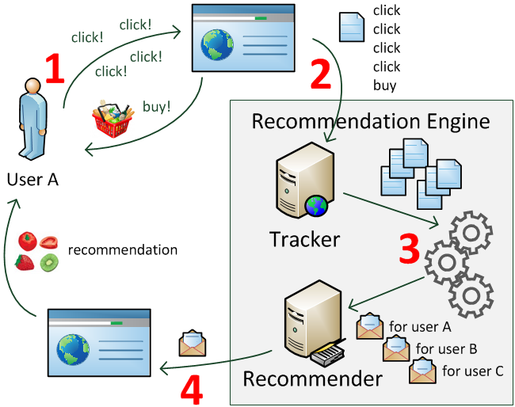

Source: [Voice Tech Podcast, “Recommendation Engine in AI”](https://medium.com/voice-tech-podcast/a-simple-way-to-explain-the-recommendation-engine-in-ai-d1a609f59d97)

A recommender learns from actions produced by earlier recommendations.

1

**Observe behavior**Clicks, purchases, and ratings reveal user preferences.

2

**Record events**The tracker stores interactions for later learning.

3

**Learn preferences**The model turns interaction history into scores.

4

**Serve recommendations**The system returns selected items to each user.

New actions become the next round of training data.

## Recommendation serving and learning

ONLINE  
Each request

**Retrieve**

Reduce the catalog to a candidate pool

*→*

**Rank**

Score the smaller pool with a richer model

*→*

**Re-rank + display**

Apply eligibility and diversity constraints

Outcomes become training data ↓**Updated models return to serving ↑**

OFFLINE  
Periodic updates

**Prepare data**

Log events and construct features

*→*

**Train + validate**

Fit models and compare their predictions

*→*

**Deploy + monitor**

Publish models and check service quality

Training and serving must use consistent feature definitions.

## This course focuses on rating prediction

### Data

Sparse user–item ratings

Identify the observed feedback and the missing pairs.

### Models

Baselines, factorization, neural models

Learn a function that predicts a rating for a user–item pair.

### Evaluation

Prediction on held-out ratings

Compare models on validation data and report final test performance.

The predicted scores can then support candidate ranking in the wider system.

## Real datasets use different names for the same roles

THREE DATASETS · ONE ABSTRACTION

| Dataset | Fields in user / item / rating order | Actual record (u, i, r) |
| --- | --- | --- |
| **Netflix** | `user_id · movie_id · rating` | `(1960, 670, 4)` |
| **CiaoDVD** | `userID · itemID · rating` | `(FA8D7A, 79CBAD, 5.0)` |
| **Book-Crossing** | `User-ID · ISBN · Book-Rating` | `(276726, 0155061224, 5)` |

(u, i, r<sub>ui</sub>) is a modeling vocabulary: IDs identify who and what; feedback records the observed preference.

## Load the table, then inspect the rows

```python
import pandas as pd

base = (
    "https://raw.githubusercontent.com/"
    "statmlben/CUHK-STAT3009/main/"
    "dataset/netflix/"
)

fields = ["movie_id", "user_id", "rating"]
train = pd.read_csv(
    base + "train.csv", usecols=fields
)
test = pd.read_csv(
    base + "test.csv", usecols=fields
)
train.head()
```

train.head()

|  | movie_id | user_id | rating |
| --- | --- | --- | --- |
| 0 | 670 | 1960 | 4 |
| 1 | 152 | 1346 | 4 |
| 2 | 1741 | 785 | 4 |
| 3 | 3032 | 686 | 5 |
| 4 | 536 | 1894 | 4 |

One row records one observed user–movie rating.

## A few checks reveal the dataset structure

```python
# rows and columns
print("shape:", train.shape)

# storage types
display(train.dtypes)

# users and movies across both splits
both = pd.concat([train, test])
ids = ["user_id", "movie_id"]
display(both[ids].nunique())

# response scale
display(train["rating"].agg(["min", "max"]))
```

SHAPE**51,161 × 3**

training observations × selected fields

CATEGORIES**2,000 users · 3,568 movies**

unique IDs across train and test

RATING RANGE**1–5**

integer-valued explicit feedback

MODEL TABLE**2 IDs · 1 target**

the columns needed for rating prediction

## Netflix data separates IDs from ratings

STORAGE TYPE ≠ MODELING ROLE

| Field | Example | Pandas | Meaning |
| --- | --- | --- | --- |
| `user_id` | 1960 | `int64` | categorical user identifier |
| `movie_id` | 670 | `int64` | categorical item identifier |
| `rating` | 4 | `int64` | ordered score and prediction target |

NETFLIX**Explicit feedback**

A 1–5 star rating directly states a preference.

CONTRAST**Implicit feedback**

A click, view, or purchase only suggests a preference.

An integer ID is a label—not a quantity. User 1960 is not “larger” than user 20.

## User and movie IDs form X; rating is y

```python
features = ["user_id", "movie_id"]

X_train = train[features].to_numpy()
y_train = train["rating"].to_numpy()

X_test = test[features].to_numpy()
y_test = test["rating"].to_numpy()
```

INPUT**`X_train` · 51,161 × 2**

Each row is `[user_id, movie_id]`.

TARGET**`y_train` · 51,161 values**

Each value is the corresponding rating.

PREDICTION TASK**Two IDs → one score**

Learn *f*<sub>θ</sub>(u, i) → *r̂*<sub>ui</sub>.

## Most user–movie pairs are unobserved

|  | Movie 0 | Movie 1 | Movie 2 | Movie 3 |
| --- | --- | --- | --- | --- |
| User 0 | 4 | ? | 5 | ? |
| User 1 | ? | 2 | ? | 4 |
| User 2 | 5 | ? | 4 | ? |
| User 3 | ? | 3 | ? | 5 |

OBSERVED**(u, i) ∈ Ω**

We know *r*<sub>ui</sub>. Split observed ratings before model selection.

UNKNOWN**(u, i) ∉ Ω**

We estimate the missing preference as *r̂*<sub>ui</sub>.

**Missing ≠ zero.**  
A blank cell means “not observed,” not “disliked.”

## New pairs and new IDs are different problems

| Test case | What training provides | In this Netflix split |
| --- | --- | --- |
| **Known IDs, new pair** | History for both IDs, but no rating for this pair | Use the learned user and movie information |
| **New user** | No training history for this user | 74 test users are absent from training |
| **New movie** | No training ratings for this movie | 584 test movies are absent from training |

For an unseen ID, define a fallback such as the training-set mean. Later models can use side information.

## Three minutes: make the data contract explicit

```python
first = train.iloc[0][
    ["user_id", "movie_id", "rating"]
]

features = ["user_id", "movie_id"]
X = train[features].to_numpy()
y = train["rating"].to_numpy()

display(first)
print("X:", X.shape, "y:", y.shape)
```

01

Write the first observation as **(u, i, r<sub>ui</sub>)**.

02

Report the shapes of **X** and **y**.

03

Explain why an integer ID is a **label**, not a continuous measurement.

04

Complete the sentence: “A missing rating means ___, not zero.”

Run it · compare with a neighbor · explain one answer aloud

## Training, validation, and test ratings

### Training

Ω<sup>tr</sup>

Fit model parameters.

Use the fitting portion of `train.csv`.

### Validation

Ω<sup>val</sup>

Choose the method and its settings.

Reserve a portion of `train.csv`.

### Test

Ω<sup>te</sup>

Report final predictive performance.

Keep `test.csv` untouched during model selection.

After choosing settings, refit on all of `train.csv`, then evaluate once on `test.csv`.

## The task is to predict held-out ratings accurately

INPUT**(u, i)**

a candidate user–movie pair

*→*

MODEL**f<sub>θ</sub>**

fitted using training ratings Ω<sup>tr</sup>

*→*

PREDICTION**r̂<sub>ui</sub>**

an estimated preference score

EVALUATE ON HELD-OUT PAIRS

Compare predictions with known ratings in Ω<sup>te</sup>.

$$\operatorname{RMSE}=\sqrt{\frac{1}{|\Omega^{\mathrm{te}}|}\sum_{(u,i)\in\Omega^{\mathrm{te}}}(r_{ui}-\hat r_{ui})^2}$$

## Training error and prediction on new ratings

This code measures training fit. What evidence would support prediction on new ratings?

```python
# X_train: user and movie IDs
# y_train: observed ratings
model.fit(X_train, y_train)

pred = model.predict(X_train)
rmse = np.sqrt(
    np.mean((y_train - pred) ** 2)
)
print(rmse)
```

**Read the code**Fitting and evaluation use the same observations.

**Interpret the number**This is training RMSE, measuring fit to the training ratings.

**Identify the missing evidence**Training RMSE alone does not establish accuracy on new ratings.

**Change the experiment**Use validation ratings to choose settings. Keep test ratings for the final report.

Coding reveals which data was used. Mathematics explains what the result can support.

## Ranking unrated candidates by predicted score

RATING PREDICTION → CANDIDATE SCORES → RANKED LIST

01 · PREDICT **For user 1960**

r̂<sub>ui</sub> = f<sub>θ</sub>(u, i)

Score candidate movies that this user has not rated.

*→*

02 · SCORE CANDIDATES **Illustrative predictions**

| Movie 13 | 4.2 |
| --- | --- |
| Movie 14 | 4.8 |
| Movie 3032 | 3.9 |

*→*

03 · SORT DESCENDING **Recommendation ranking**

| 1 | Movie 14 | 4.8 |
| --- | --- | --- |
| 2 | Movie 13 | 4.2 |
| 3 | Movie 3032 | 3.9 |

COURSE FOCUS**Learn the scoring function**

Estimate ratings accurately from sparse observations and evaluate with held-out RMSE.

SYSTEM USE**Turn scores into an ordered list**

Rank candidates by predicted preference, then apply later serving constraints.

Observed ratings → rating model → predicted scores → ranked list → user actions → new observations

## Offline accuracy is a gate—not the final outcome

MODEL → SYSTEM → PRODUCT

01 · MODEL**Held-out RMSE**

Can predicted ratings generalize to unseen user–item pairs?

02 · SYSTEM**Latency · reliability · coverage**

Can the service respond quickly and consistently for real users?

03 · PRODUCT**Satisfaction · engagement · retention**

Does the full experience improve the intended user outcome?

OFFLINE VALIDATION*→*ONLINE EXPERIMENT*→*MONITOR AFTER LAUNCH

The objective shapes the behavior of the system. A better model metric does not automatically imply a better product.

## Ready for the first lab?

**01** Bring a laptop **02** Open the notebook **03** Run the setup cell **04** Trace ratings → scores → ranked list → new feedback

[bendai.org/CUHK-STAT3009 ↗](https://www.bendai.org/CUHK-STAT3009/)